# A Brief Introduction to Programming with R

10/09/2021

## The Plan for Today

- 09:15-10:00 *Introduction, Background, Tools*
- 10:00-10:15 *Break, support with installations*
- 10:15-11:00 *Exercises, First Steps with R*
- 11:00-11:15 *Break, Q&A*
- 11:15-12:00 *First Steps with R, Concepts*
- 12:00-13:15 *Lunch (individually)*
- 13:15-14:00 *Exercises*
- 14:00-14:15 *Break, Q&A*
- 14:15-15:00 *Working with Data*

## Loading/Importing Data

## Loading built-in R data sets

In order to load built-in data sets, simply use the `data()`-function:

```r
data(swiss)
```

Results in an object called `swiss` in the global environment.

```r
# inspect the structure
str(swiss)

# look at the first few rows
head(swiss)
```

## Comma Separated Values (CSV)

The first line of `swiss` stored as a csv-file:

```
"","Fertility","Agriculture","Examination","Education","Catholic","Infant.Mortality"
"Courtelary",80.2,17,15,12,9.96,22.2
```

## Importing data from CSVs

```r
swiss_imported <- read.csv("data/swiss.csv")
```

## Spreadsheets/Excel

In order to read excel spreadsheets we need to install an additional R package called `readxl`.

```r
# install the package
install.packages("readxl")
```

```r
# load the package
library(readxl)

# import data from a spreadsheet
swiss_imported <- read_excel("data/swiss.xlsx")
```

## Import data from other data analysis software

- The R packages `foreign` and `haven` contain functions to import data from formats used in other statistics/data analysis software, such as SPSS (`.sav`) and STATA (`.dat`).
- In the following example we use `haven`‘s `read_spss()` function to import a version of the `swiss`-data set stored in SPSS’ `.sav`-format (again stored in the folder called `data`).

```r
# install the package (if not yet installed):
# install.packages("haven")

# load the package
library(haven)

# read the data
swiss_imported <- read_spss("data/swiss.sav")
```

## `ggplot2`

[figure not shown]

## `ggplot2` basics

- Data must be stored in a `data.frame`
- Basic function/starting point of a plot: `ggplot`
- First line of plot code declares the data and the ‘aesthetics’ (what variables are mapped to the x-/y-axes):

```r
ggplot(data = my_dataframe, aes(x= xvar, y= yvar))
```

## Example data set: `swiss`

```r
# load the R package
library(ggplot2)
# load the data
data(swiss)
# get details about the data set
# ?swiss
# inspect the data
head(swiss)
```

```
##              Fertility Agriculture Examination Education Catholic Infant.Mortality
## Courtelary        80.2        17.0          15        12     9.96             22.2
## Delemont          83.1        45.1           6         9    84.84             22.2
## Franches-Mnt      92.5        39.7           5         5    93.40             20.2
## Moutier           85.8        36.5          12         7    33.77             20.3
## Neuveville        76.9        43.5          17        15     5.16             20.6
## Porrentruy        76.1        35.3           9         7    90.57             26.6
```

## Add indicator variable

Code a province as ‘Catholic’ if more than 50% of the inhabitants are catholic:

```r
swiss$Religion <- 'Protestant'
swiss$Religion[50 < swiss$Catholic] <- 'Catholic'
swiss$Religion <- as.factor(swiss$Religion)
```

## Data and aesthetics

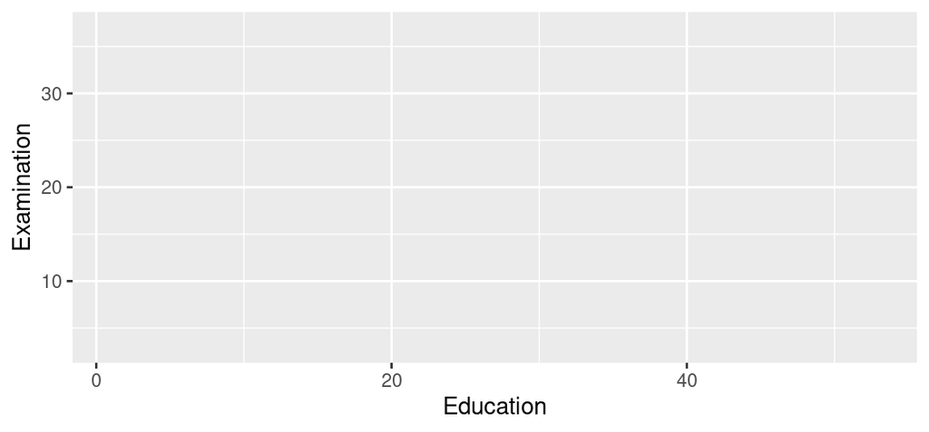

```r
ggplot(data = swiss, aes(x = Education, y = Examination))
```

## Geometries (~the type of plot)

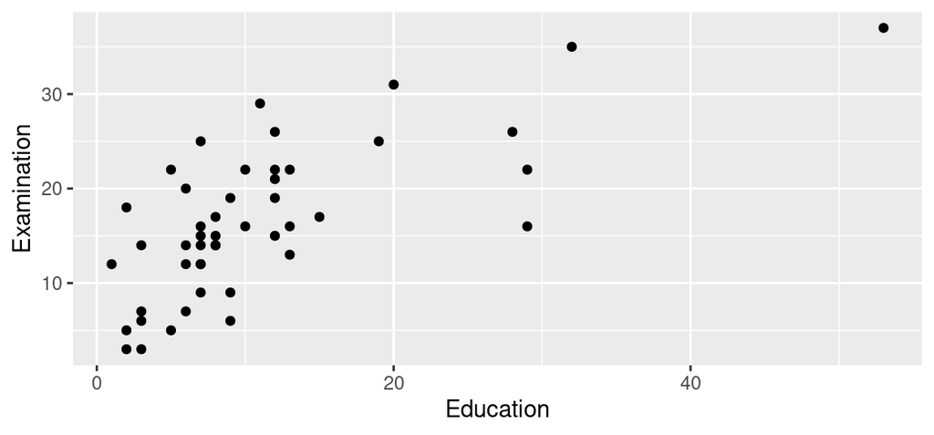

```r
ggplot(data = swiss, aes(x = Education, y = Examination)) +
     geom_point()
```

## Facets

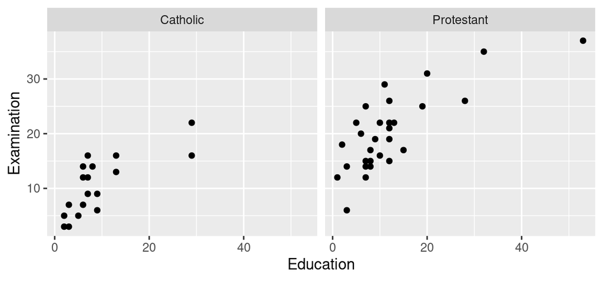

```r
ggplot(data = swiss, aes(x = Education, y = Examination)) +
     geom_point() +
     facet_wrap(~Religion)
```

## Additional layers and statistics

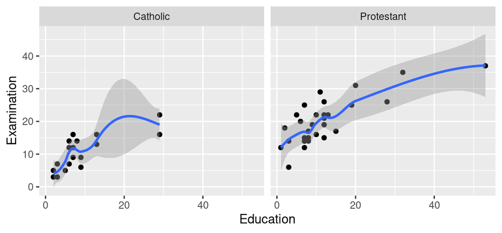

```r
ggplot(data = swiss, aes(x = Education, y = Examination)) +
     geom_point() +
     geom_smooth(method = 'loess') +
     facet_wrap(~Religion)
```

## Additional layers and statistics

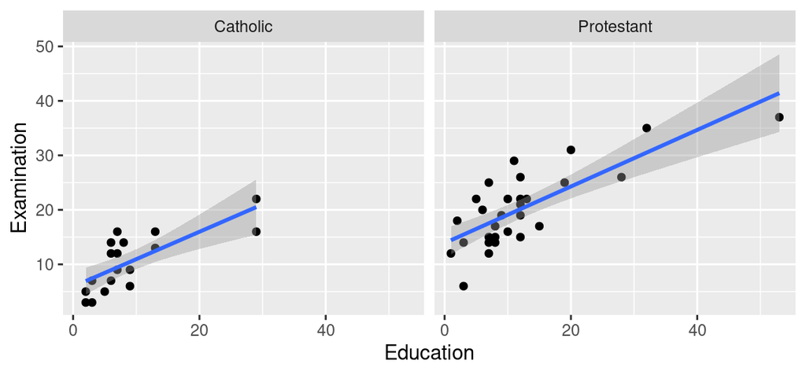

```r
ggplot(data = swiss, aes(x = Education, y = Examination)) +
     geom_point() +
     geom_smooth(method = 'lm') +
     facet_wrap(~Religion)
```

## Additional aesthetics

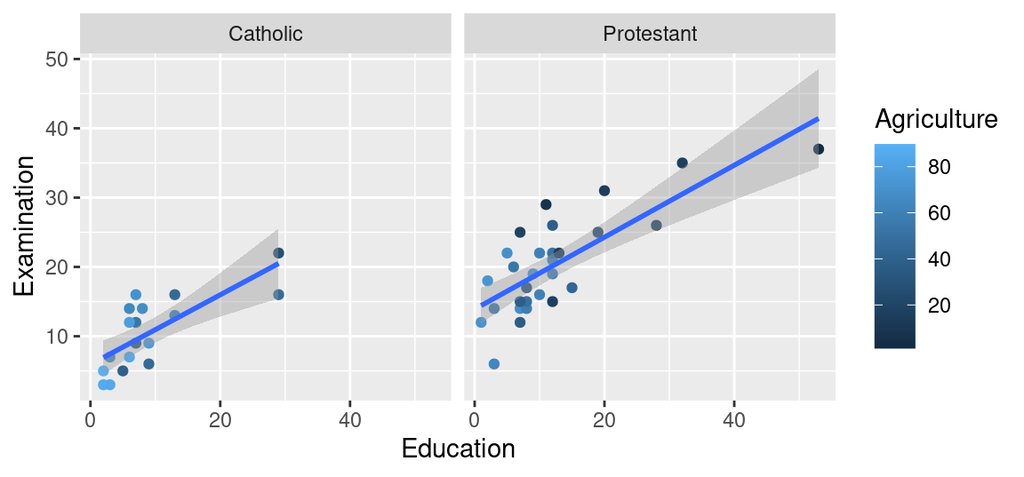

```r
ggplot(data = swiss, aes(x = Education, y = Examination)) +
     geom_point(aes(color = Agriculture)) +
     geom_smooth(method = 'lm') +
     facet_wrap(~Religion)
```

## Change coordinates

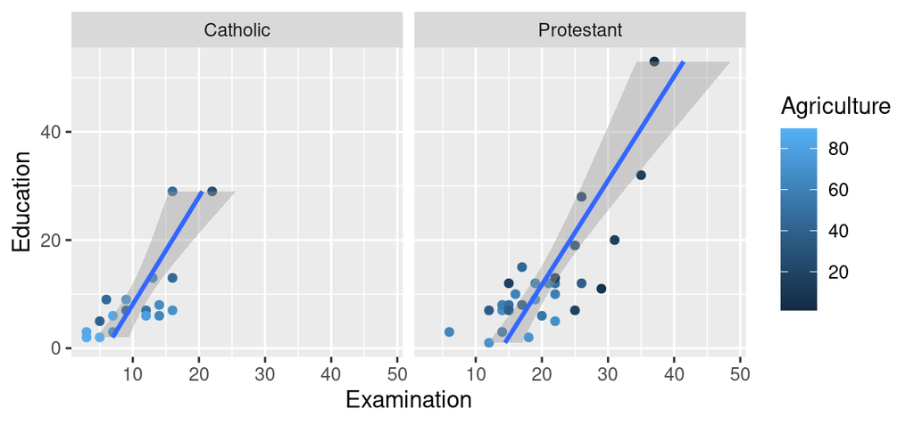

```r
ggplot(data = swiss, aes(x = Education, y = Examination)) +
     geom_point(aes(color = Agriculture)) +
     geom_smooth(method = 'lm') +
     facet_wrap(~Religion) +
     coord_flip()
```

## Themes

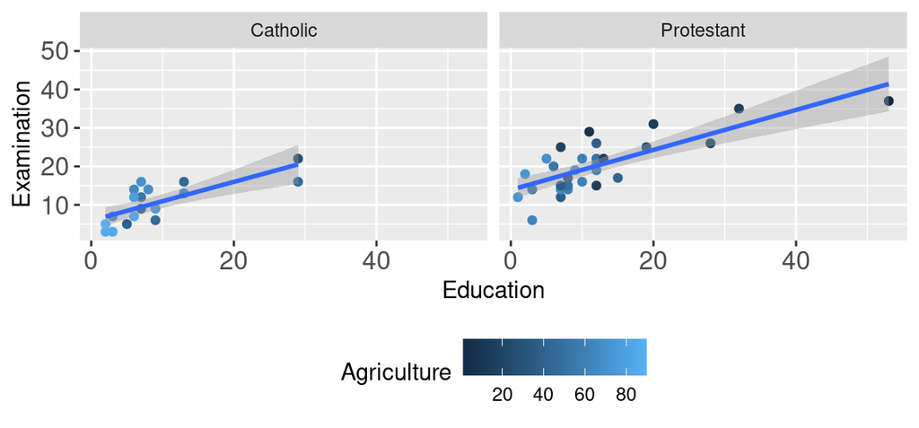

```r
ggplot(data = swiss, aes(x = Education, y = Examination)) +
     geom_point(aes(color = Agriculture)) +
     geom_smooth(method = 'lm') +
     facet_wrap(~Religion) +
     theme(legend.position = "bottom", axis.text=element_text(size=12) )
```

## Themes

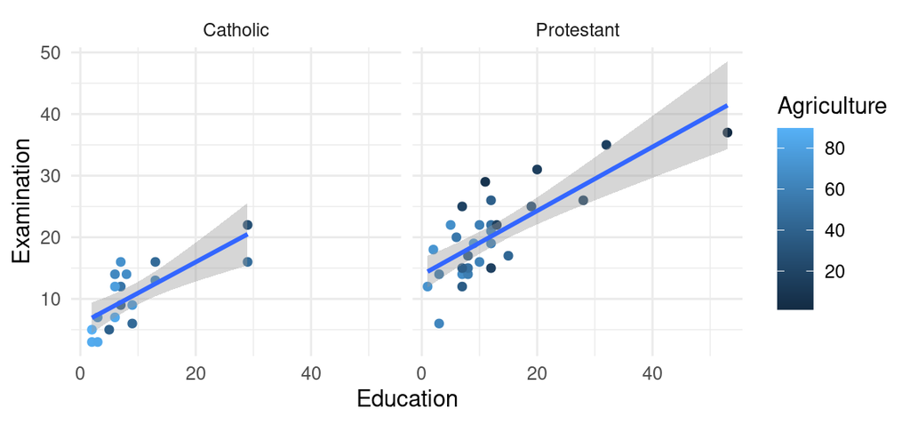

```r
ggplot(data = swiss, aes(x = Education, y = Examination)) +
     geom_point(aes(color = Agriculture)) +
     geom_smooth(method = 'lm') +
     facet_wrap(~Religion) +
     theme_minimal()
```

## Themes

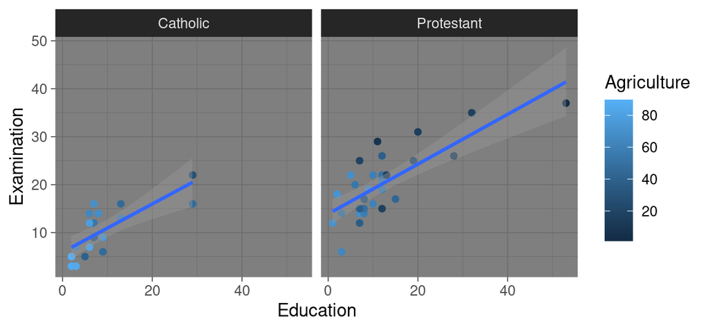

```r
ggplot(data = swiss, aes(x = Education, y = Examination)) +
     geom_point(aes(color = Agriculture)) +
     geom_smooth(method = 'lm') +
     facet_wrap(~Religion) +
     theme_dark()
```

## Basic Statistics with R

## Mean and median

```r
# initiate sample
a <- c(10,22,33, 22, 40)
names(a) <- c("Andy", "Betty", "Claire", "Daniel", "Eva")

# compute the mean
mean(a)
```

```
## [1] 25.4
```

```r
# compute the median
median(a)
```

```
## [1] 22
```

## Measures of variability

```r
range(a)
```

```
## [1] 10 40
```

```r
var(a)
```

```
## [1] 132.8
```

```r
sd(a)
```

```
## [1] 11.52389
```

## T-test

```r
# define size of sample
n <- 100
# draw the random sample from a normal distribution with mean 10 and sd 2
sample <- rnorm(n, mean = 10, sd = 2)

# Test H0: mean of population = 10
t.test(sample, mu = 10)
```

```
##
##  One Sample t-test
##
## data:  sample
## t = 0.22933, df = 99, p-value = 0.8191
## alternative hypothesis: true mean is not equal to 10
## 95 percent confidence interval:
##   9.644858 10.447963
## sample estimates:
## mean of x
##  10.04641
```

## Regression analysis with R

- In `formula`, we define the model we want to fit as an object of class ‘formula.’

```r
model1 <- Examination~Education
```

- Fit the model with the respective estimator (here OLS: `lm()`).

```r
fit1 <- lm(formula = model1, data = swiss)
```

- Get summary statistics with the generic `summary()`.

```r
summary(fit1)
```

## Simple linear regressions

```r
# load data
data(swiss)

# linear regression with one variable
# estimate coefficients
model_fit <- lm(Examination~Education, data = swiss)
# t-tests of coefficients (and additional statistics)
summary(model_fit)
```

```
##
## Call:
## lm(formula = Examination ~ Education, data = swiss)
##
## Residuals:
##      Min       1Q   Median       3Q      Max
## -10.9322  -4.7633  -0.1838   3.8907  12.4983
##
## Coefficients:
##             Estimate Std. Error t value Pr(>|t|)
## (Intercept) 10.12748    1.28589   7.876 5.23e-10 ***
## Education    0.57947    0.08852   6.546 4.81e-08 ***
## ---
## Signif. codes:  0 '***' 0.001 '**' 0.01 '*' 0.05 '.' 0.1 ' ' 1
##
## Residual standard error: 5.773 on 45 degrees of freedom
## Multiple R-squared:  0.4878, Adjusted R-squared:  0.4764
## F-statistic: 42.85 on 1 and 45 DF,  p-value: 4.811e-08
```

```r
# multiple linear regression
# estimate coefficients
model_fit2 <- lm(Examination~Education + Catholic + Agriculture, data = swiss)
# t-tests of coefficients (and additional statistics)
summary(model_fit2)
```

```
##
## Call:
## lm(formula = Examination ~ Education + Catholic + Agriculture,
##     data = swiss)
##
## Residuals:
##     Min      1Q  Median      3Q     Max
## -9.3146 -2.8308 -0.3486  3.3494  7.4172
##
## Coefficients:
##             Estimate Std. Error t value Pr(>|t|)
## (Intercept) 18.53695    2.63707   7.029 1.17e-08 ***
## Education    0.42418    0.08678   4.888 1.46e-05 ***
## Catholic    -0.07976    0.01679  -4.750 2.29e-05 ***
## Agriculture -0.06757    0.03963  -1.705   0.0954 .
## ---
## Signif. codes:  0 '***' 0.001 '**' 0.01 '*' 0.05 '.' 0.1 ' ' 1
##
## Residual standard error: 4.304 on 43 degrees of freedom
## Multiple R-squared:  0.7279, Adjusted R-squared:  0.7089
## F-statistic: 38.35 on 3 and 43 DF,  p-value: 3.212e-12
```

## Other econometric models

- Probit model: `glm(..., family = binomial(link = "probit"))`.
- Logit model: `glm(..., family = "binomial")`.
- Poisson regression (count data): `glm(..., family="poisson")`.

## Other econometric models

Other frequently used packages for econometric regression analysis:

- Panel data econometrics: package `plm`, `fixest`, `lfe`.
- Time-series econometrics: package `tseries`.
- Basic IV regression: `ivreg()` in package `AER`.
- Generalized methods of moments: package `gmm`.
- Generalized additive models: package `gam`.
- Lasso regression: package `glmnet`.
- Survival analysis: package `survival`.

See also the [CRAN Econometrics Task View](https://cran.r-project.org/web/views/Econometrics.html)

## Print results: Text

```r
# load packages
library(stargazer)

# print regression results as text
stargazer(model_fit, model_fit2, type = "text")
```

```
##
## =================================================================
##                                  Dependent variable:
##                     ---------------------------------------------
##                                      Examination
##                              (1)                    (2)
## -----------------------------------------------------------------
## Education                  0.579***               0.424***
##                            (0.089)                (0.087)
##
## Catholic                                         -0.080***
##                                                   (0.017)
##
## Agriculture                                       -0.068*
##                                                   (0.040)
##
## Constant                  10.127***              18.537***
##                            (1.286)                (2.637)
##
## -----------------------------------------------------------------
## Observations                  47                     47
## R2                          0.488                  0.728
## Adjusted R2                 0.476                  0.709
## Residual Std. Error    5.773 (df = 45)        4.304 (df = 43)
## F Statistic         42.854*** (df = 1; 45) 38.347*** (df = 3; 43)
## =================================================================
## Note:                                 *p<0.1; **p<0.05; ***p<0.01
```

## Print results: Latex

```r
# print regression results as latex
stargazer(model_fit, model_fit2, type = "latex")
```

```
##
## % Table created by stargazer v.5.2.2 by Marek Hlavac, Harvard University. E-mail: hlavac at fas.harvard.edu
## % Date and time: Tue, Aug 17, 2021 - 04:53:12 PM
## \begin{table}[!htbp] \centering
##   \caption{}
##   \label{}
## \begin{tabular}{@{\extracolsep{5pt}}lcc}
## \\[-1.8ex]\hline
## \hline \\[-1.8ex]
##  & \multicolumn{2}{c}{\textit{Dependent variable:}} \\
## \cline{2-3}
## \\[-1.8ex] & \multicolumn{2}{c}{Examination} \\
## \\[-1.8ex] & (1) & (2)\\
## \hline \\[-1.8ex]
##  Education & 0.579$^{***}$ & 0.424$^{***}$ \\
##   & (0.089) & (0.087) \\
##   & & \\
##  Catholic &  & $-$0.080$^{***}$ \\
##   &  & (0.017) \\
##   & & \\
##  Agriculture &  & $-$0.068$^{*}$ \\
##   &  & (0.040) \\
##   & & \\
##  Constant & 10.127$^{***}$ & 18.537$^{***}$ \\
##   & (1.286) & (2.637) \\
##   & & \\
## \hline \\[-1.8ex]
## Observations & 47 & 47 \\
## R$^{2}$ & 0.488 & 0.728 \\
## Adjusted R$^{2}$ & 0.476 & 0.709 \\
## Residual Std. Error & 5.773 (df = 45) & 4.304 (df = 43) \\
## F Statistic & 42.854$^{***}$ (df = 1; 45) & 38.347$^{***}$ (df = 3; 43) \\
## \hline
## \hline \\[-1.8ex]
## \textit{Note:}  & \multicolumn{2}{r}{$^{*}$p$<$0.1; $^{**}$p$<$0.05; $^{***}$p$<$0.01} \\
## \end{tabular}
## \end{table}
```

## Print results: HTML

```r
# print regression results as text
stargazer(model_fit, model_fit2, type = "html")
```

|  | *Dependent variable:* |  |
| --- | --- | --- |
|  | Examination |  |
|  | (1) | (2) |
| Education | 0.579*** | 0.424*** |
|  | (0.089) | (0.087) |
| Catholic |  | -0.080*** |
|  |  | (0.017) |
| Agriculture |  | -0.068* |
|  |  | (0.040) |
| Constant | 10.127*** | 18.537*** |
|  | (1.286) | (2.637) |
| Observations | 47 | 47 |
| R<sup>2</sup> | 0.488 | 0.728 |
| Adjusted R<sup>2</sup> | 0.476 | 0.709 |
| Residual Std. Error | 5.773 (df = 45) | 4.304 (df = 43) |
| F Statistic | 42.854*** (df = 1; 45) | 38.347*** (df = 3; 43) |
| *Note:* | p<0.1; p<0.05; p<0.01 |  |